# A Quick Look at Crypto Currencies with R

Dr. Aous "Alex" Abdo info@analyticadss.com

No doubt that crypto currencies with all the promises they bring, both financially and otherwise, are only here to stay. As a data scientist interested in data and numbers, I thought it would be nice to take a look at some crypto currencies with my favorite tool, [R](https://cran.r-project.org/).

## R Libraries

Below is a list of R libraries we will be using to help us with our analysis. Not all of them are necessary but they all will make our life easier.

```r
library(PoloniexR)
library(data.table)
library(lubridate)
library(Quandl)
library(plyr)
library(stringr)
library(ggplot2)
library(plotly)
library(janitor)
library(quantmod)
library(pryr)
library(corrplot)
library(PerformanceAnalytics)
library(tidyr)
library(MLmetrics)
library(tidyquant)
library(corrr)
library(cowplot)
```

## Getting the Data

### 2. Quandl

[Quandl](https://www.quandl.com) is my go to place for any financial data. Their free-tier API has lots of good data one can use. Quandl offers data from multiple exchanges. Locating crypto data on Quandl is not straight forward. After spending few hours on their site I found out that most of the crypto data can be found [here](https://www.quandl.com/data/BITFINEX-Bitfinex)

First, let’s take a look at different exchange data for Bitcoin using Quandl. We will download and plot historical bitcoin data from the following exchanges Kraken, Coinbase, Bitstamp, and ITBIT

```r
# function to download quandl data
get_quandl_data <- function(data_source = "BITFINEX"
                            , pair = 'btcusd'
                            , ...){

  # make sure the user supplied the correct data_source
  if(toupper(data_source) != "BITFINEX") stop("data source supplied is wrong...")
  # quandl is case sensitive, all codes have to be upper case
  pair <- toupper(pair)
  tmp <- NA
  try(tmp <- Quandl(code = toupper(paste(data_source, pair, sep = "/")), ...), silent = TRUE)
  return(tmp)
}
# get btc data from different exchanges
  exchange_data <- list()

  exchanges <- c('KRAKENUSD','COINBASEUSD','BITSTAMPUSD','ITBITUSD')

  for (i in exchanges){
    print(paste0('BCHARTS/', i))
    exchange_data[[i]] <- Quandl(paste0('BCHARTS/', i))
  }
```

```
[1] "BCHARTS/KRAKENUSD"
[1] "BCHARTS/COINBASEUSD"
[1] "BCHARTS/BITSTAMPUSD"
[1] "BCHARTS/ITBITUSD"
```

We need to convert this list of BTC prices from different exchanges into a dataframe and put them all in one data frame so we can plot them.

```r
# put them all in one dataframe to plot in ggplot2
btc_usd <- do.call("rbind", exchange_data)
btc_usd$exchange <- row.names(btc_usd)
btc_usd <- as.data.table(btc_usd)
```

We also need to do some minor cleaning, so let’s do that. We also need to get rid of rows of data with 0 weighted price.

```r
# some data cleaning
btc_usd[, exchange := as.factor(str_extract(exchange, "[A-Z]+"))]
btc_usd <- clean_names(btc_usd)
btc_usd <- btc_usd[weighted_price > 0]
setkey(btc_usd, date)
```

Let’s take a look at the data table we just made.

```r
head(btc_usd)
```

| date | open | high | low | close | volume_btc | volume_currency | weighted_price | exchange |
| --- | --- | --- | --- | --- | --- | --- | --- | --- |
| 2011-09-13 | 5.80 | 6.00 | 5.65 | 5.97 | 58.37138 | 346.0974 | 5.929231 | BITSTAMPUSD |
| 2011-09-14 | 5.58 | 5.72 | 5.52 | 5.53 | 61.14598 | 341.8548 | 5.590798 | BITSTAMPUSD |
| 2011-09-15 | 5.12 | 5.24 | 5.00 | 5.13 | 80.14080 | 408.2590 | 5.094272 | BITSTAMPUSD |
| 2011-09-16 | 4.82 | 4.87 | 4.80 | 4.85 | 39.91401 | 193.7631 | 4.854515 | BITSTAMPUSD |
| 2011-09-17 | 4.87 | 4.87 | 4.87 | 4.87 | 0.30000 | 1.4610 | 4.870000 | BITSTAMPUSD |
| 2011-09-18 | 4.87 | 4.92 | 4.81 | 4.92 | 119.81280 | 579.8431 | 4.839576 | BITSTAMPUSD |

Now we’ll look at the price of bitcoin and color code it by exchange.

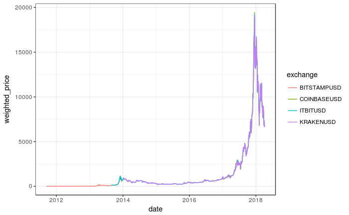

```r
ggplot(btc_usd, aes(x = date, y = weighted_price, col = exchange)) + geom_line() + theme_bw()
```

```r
p <- ggplot(btc_usd[date >= ymd("2018-01-01") & date <= ymd("2018-01-31")], aes(x = date, y = weighted_price, col = exchange)) + geom_line() + theme_bw()
ggplotly(p)
```

[interactive chart not shown]

There are obvious difference in prices, which seem to vary over time as well.

```r
btc_usd_average_price <- btc_usd[, mean(weighted_price), by = date]
setnames(btc_usd_average_price, c("date", "averaged_price"))
```

Now let’s make some plots